# Harmony R Walkthrough

# Harmony walkthrough - R library

[figure not shown]

This notebook shows how you can use Harmony to find the similarity matrix between two questionnaires.

The Harmony project is a data harmonisation project that uses [Natural Language Processing](https://fastdatascience.com/guide-natural-language-processing-nlp/) to help researchers make better use of existing data from different studies by supporting them with the harmonisation of various measures and items used in different studies.

Harmony is a collaboration project between [Ulster University](https://ulster.ac.uk/), [University College London](https://ucl.ac.uk/), the [Universidade Federal de Santa Maria](https://www.ufsm.br/), and [Fast Data Science](http://fastdatascience.com/). Harmony is funded by [Wellcome](https://wellcome.org/) as part of the [Wellcome Data Prize in Mental Health](https://wellcome.org/grant-funding/schemes/wellcome-mental-health-data-prize).

First let’s install and import Harmony. If you haven’t already, you need to install it with `install.packages("harmonydata")`.

```r
#install.packages("harmonydata")
```

```r
library(harmonydata)
```

Now we can create our instruments.

If you had everything in a PDF or Excel file, you could load the instruments directly from the file: `instrument = load_instruments_from_file(path = "CBCL_GOASSESS.xlsx")`. In this example we will load two questionnaires from Harmony’s database and manually input a third questionnaire.

First we load the instruments from Harmony’s database:

```r
example_instruments <- get_example_instruments()
names(example_instruments)
```

```
##  [1] "CES_D English"
##  [2] "SCARED English (adult)"
##  [3] "SCARED English (child)"
##  [4] "GAD-7 Portuguese"
##  [5] "De Jong Gierveld Loneliness Scale English"
##  [6] "Market research survey fictional soft drink English"
##  [7] "GAD-7 English"
##  [8] "GHQ 12 English"
##  [9] "Market research survey template English"
## [10] "Adult ADHD Self-Report Scale English"
## [11] "MacLean Screening Instrument for BPD English"
## [12] "RCADS Child Reported English"
## [13] "GAD-7 French"
## [14] "GAD-7 German"
## [15] "GAD-7 Spanish"
## [16] "GAD-7 Russian"
## [17] "GAD-7 Chinese"
## [18] "GAD-7 Afrikaans"
## [19] "GAD-7 Cebuano"
## [20] "GAD-7 Kannada"
## [21] "GAD-7 Hebrew"
## [22] "GAD-7 Norwegian"
```

Let’s use the CES-D English, GAD-7 Portuguese and create a GAD-7 Norwegian instrument.

```r
ces_d_english <- example_instruments[["CES_D English"]]
gad_7_portuguese <- example_instruments[["GAD-7 Portuguese"]]

gad_7_norwegian <- create_instrument_from_list(
    list(
        "Følt deg nervøs, engstelig eller veldig stresset",
        "Ikke klart å slutte å bekymre deg eller kontrolleren bekymringene dine"
    ),
    instrument_name = "GAD-7 Norwegian"
)
```

We can concatenate our instruments together:

```r
instruments_list <- list(ces_d_english, gad_7_portuguese, gad_7_norwegian)
```

Let’s call Harmony to calculate the match:

```r
match <- match_instruments(instruments_list, topics=list("anxiety", "depression", "bother"))
```

```r
help(match_instruments)
```

```
## starting httpd help server ... done
```

**Check** what has come out of the match:

```r
names(match)
```

```
## [1] "instruments"
## [2] "questions"
## [3] "matches"
## [4] "query_similarity"
## [5] "closest_catalogue_instrument_matches"
## [6] "instrument_to_instrument_similarities"
## [7] "clusters"
## [8] "response_options_similarity"
```

The first question is CES_D English question 1.

```r
match$questions[[1]]
```

```
## $question_no
## [1] "1"
##
## $question_text
## [1] "I was bothered by things that usually don’t bother me."
##
## $options
## $options[[1]]
## [1] "Rarely or none of the time (less than 1 day)"
##
## $options[[2]]
## [1] "Some or a little of the time (1-2 days)"
##
## $options[[3]]
## [1] "Occasionally or a moderate amount of time (3-4 days)"
##
## $options[[4]]
## [1] "Most or all of the time (5-7 days)"
##
##
## $source_page
## [1] 0
##
## $instrument_id
## [1] "b45b7169e711414582768b8c8431027c"
##
## $topics
## $topics[[1]]
## [1] "bother"
##
##
## $topics_auto
## $topics_auto[[1]]
## [1] "depression"
##
##
## $topics_strengths
## $topics_strengths$depression
## [1] 0.9928043
##
```

[output cut: 25 more lines]

```
##
## $nearest_match_from_mhc_auto$topics_auto
## NULL
##
## $nearest_match_from_mhc_auto$topics_strengths
## NULL
##
## $nearest_match_from_mhc_auto$nearest_match_from_mhc_auto
## NULL
##
## $nearest_match_from_mhc_auto$closest_catalogue_question_match
## NULL
##
## $nearest_match_from_mhc_auto$seen_in_catalogue_instruments
## NULL
```

The total number of questions is:

```r
length(match$questions)
```

```
## [1] 29
```

We can view the first few rows of the similarity matrix for the questions.

```r
head(match$matches)
```

|  | 1 I was bothered by things that usually don’t bother me. | 2 I did not feel like eating; my appetite was poor. | 3 I felt that I could not shake off the blues even with help from my family or friends. | 4 I felt I was just as good as other people. | 5 I had trouble keeping my mind on what I was doing. | 6 I felt depressed. | 7 I felt that everything I did was an effort. | 8 I felt hopeful about the future. | 9 I thought my life had been a failure. | 10 I felt fearful. | 11 My sleep was restless. | 12 I was happy. | 13 I talked less than usual. | 14 I felt lonely. | 15 People were unfriendly. | 16 I enjoyed life. | 17 I had crying spells. | 18 I felt sad. | 19 I felt that people dislike me. | 20 I could not get “going.” | 1 Sentir-se nervoso/a, ansioso/a ou muito tenso/a | 2 Não ser capaz de impedir ou de controlar as preocupações | 3 Preocupar-se muito com diversas coisas | 4 Dificuldade para relaxar | 5 Ficar tão agitado/a que se torna difícil permanecer sentado/a | 6 Ficar facilmente aborrecido/a ou irritado/a | 7 Sentir medo como se algo horrível fosse acontecer | 1 Følt deg nervøs, engstelig eller veldig stresset | 2 Ikke klart å slutte å bekymre deg eller kontrolleren bekymringene dine |
| --- | --- | --- | --- | --- | --- | --- | --- | --- | --- | --- | --- | --- | --- | --- | --- | --- | --- | --- | --- | --- | --- | --- | --- | --- | --- | --- | --- | --- | --- |
| 1 I was bothered by things that usually don’t bother me. | 1.0000000 | 0.3136500 | 0.3432307 | -0.2608283 | 0.4278881 | 0.3405483 | -0.3074892 | -0.1844938 | -0.2591457 | 0.3123279 | 0.2805717 | -0.2810103 | 0.4857708 | 0.2721404 | -0.2800038 | -0.1989061 | 0.2869449 | 0.3109423 | 0.3754597 | 0.2882913 | 0.3378802 | 0.4429031 | 0.4387079 | -0.26580209 | 0.3878320 | 0.5300115 | 0.2584586 | 0.3483438 | 0.4759780 |
| 2 I did not feel like eating; my appetite was poor. | 0.3136500 | 1.0000000 | 0.3253127 | -0.3844967 | -0.3938281 | -0.4360754 | -0.4443424 | -0.2370180 | -0.4699656 | -0.3660821 | -0.3449357 | -0.2956176 | 0.3629988 | 0.3855065 | -0.2076230 | -0.3017449 | -0.4111851 | -0.4271794 | -0.3394136 | 0.3795191 | -0.3170622 | 0.1143586 | -0.1107869 | -0.19496467 | -0.2502767 | -0.1438234 | -0.2480338 | -0.2999410 | -0.1247651 |
| 3 I felt that I could not shake off the blues even with help from my family or friends. | 0.3432307 | 0.3253127 | 1.0000000 | -0.4572784 | 0.3600379 | 0.4461865 | -0.4240063 | -0.3070913 | -0.4090989 | 0.3407558 | -0.2236730 | -0.3927100 | -0.2237019 | 0.3298419 | -0.2240179 | -0.2790295 | -0.4055312 | 0.3980323 | 0.3333253 | 0.5022725 | -0.2473898 | 0.3689574 | -0.2246580 | -0.30274118 | 0.2995582 | -0.2420086 | -0.3136669 | -0.2620691 | 0.3011257 |
| 4 I felt I was just as good as other people. | -0.2608283 | -0.3844967 | -0.4572784 | 1.0000000 | -0.4569577 | -0.4227796 | 0.3870321 | 0.3036616 | -0.5226836 | -0.3991098 | -0.2377619 | 0.5163324 | -0.3410804 | -0.3767204 | -0.3634026 | 0.4320105 | -0.3503849 | -0.4186762 | -0.4891295 | -0.3347450 | -0.2370714 | -0.1197432 | -0.1870206 | -0.08848838 | -0.2003901 | -0.1840171 | -0.2976140 | -0.2145504 | -0.1502534 |
| 5 I had trouble keeping my mind on what I was doing. | 0.4278881 | -0.3938281 | 0.3600379 | -0.4569577 | 1.0000000 | 0.4661298 | 0.4215717 | -0.3835386 | 0.4345674 | 0.4801742 | 0.4149681 | -0.4282185 | 0.3995716 | 0.3118243 | 0.1871167 | -0.3302681 | 0.3876780 | 0.4053666 | 0.3504265 | 0.5536180 | 0.3233571 | 0.3584794 | 0.3913057 | -0.28819365 | 0.3857854 | 0.2309111 | 0.3112746 | 0.3266130 | 0.4051712 |
| 6 I felt depressed. | 0.3405483 | -0.4360754 | 0.4461865 | -0.4227796 | 0.4661298 | 1.0000000 | 0.3766690 | 0.3778587 | 0.6105928 | 0.6234880 | 0.3890580 | -0.5056132 | 0.3023000 | 0.6345771 | 0.1413898 | -0.3053482 | 0.7211359 | 0.8496906 | 0.4866536 | 0.4031319 | 0.5902460 | 0.1959993 | 0.3799167 | 0.34379200 | 0.5652907 | 0.3365583 | 0.5824768 | 0.5735959 | 0.3399480 |

We can also plot a heat map of the questions similarity matrix. Please bare in mind however that R will compress the matrix to fit the size of the plotting area, which may reduce the visible resolution for large matrices.

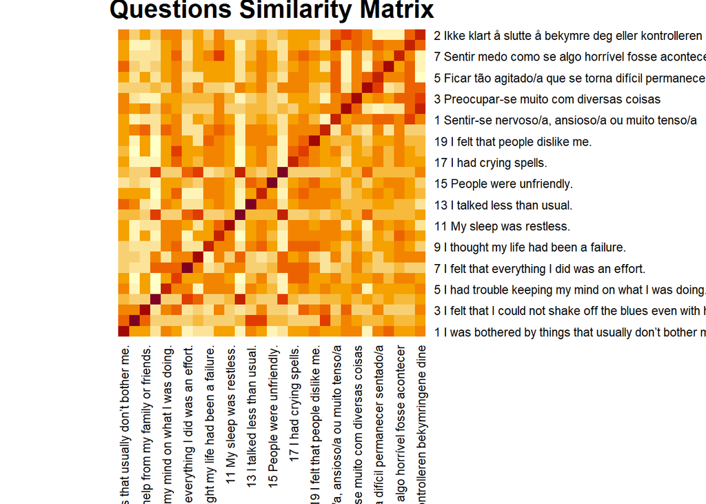

```r
heatmap(as.matrix(match$matches),
        Rowv = NA, Colv = NA, main = "Questions Similarity Matrix",
        margins = c(10, 10))
```

We can view the first few rows of the similarity matrix for the response options.

```r
head(match$response_options_similarity)
```

|  | 1 I was bothered by things that usually don’t bother me. | 2 I did not feel like eating; my appetite was poor. | 3 I felt that I could not shake off the blues even with help from my family or friends. | 4 I felt I was just as good as other people. | 5 I had trouble keeping my mind on what I was doing. | 6 I felt depressed. | 7 I felt that everything I did was an effort. | 8 I felt hopeful about the future. | 9 I thought my life had been a failure. | 10 I felt fearful. | 11 My sleep was restless. | 12 I was happy. | 13 I talked less than usual. | 14 I felt lonely. | 15 People were unfriendly. | 16 I enjoyed life. | 17 I had crying spells. | 18 I felt sad. | 19 I felt that people dislike me. | 20 I could not get “going.” | 1 Sentir-se nervoso/a, ansioso/a ou muito tenso/a | 2 Não ser capaz de impedir ou de controlar as preocupações | 3 Preocupar-se muito com diversas coisas | 4 Dificuldade para relaxar | 5 Ficar tão agitado/a que se torna difícil permanecer sentado/a | 6 Ficar facilmente aborrecido/a ou irritado/a | 7 Sentir medo como se algo horrível fosse acontecer |
| --- | --- | --- | --- | --- | --- | --- | --- | --- | --- | --- | --- | --- | --- | --- | --- | --- | --- | --- | --- | --- | --- | --- | --- | --- | --- | --- | --- |
| 1 I was bothered by things that usually don’t bother me. | 1 | 1 | 1 | 1 | 1 | 1 | 1 | 1 | 1 | 1 | 1 | 1 | 1 | 1 | 1 | 1 | 1 | 1 | 1 | 1 | 0.809019 | 0.809019 | 0.809019 | 0.809019 | 0.809019 | 0.809019 | 0.809019 |
| 2 I did not feel like eating; my appetite was poor. | 1 | 1 | 1 | 1 | 1 | 1 | 1 | 1 | 1 | 1 | 1 | 1 | 1 | 1 | 1 | 1 | 1 | 1 | 1 | 1 | 0.809019 | 0.809019 | 0.809019 | 0.809019 | 0.809019 | 0.809019 | 0.809019 |
| 3 I felt that I could not shake off the blues even with help from my family or friends. | 1 | 1 | 1 | 1 | 1 | 1 | 1 | 1 | 1 | 1 | 1 | 1 | 1 | 1 | 1 | 1 | 1 | 1 | 1 | 1 | 0.809019 | 0.809019 | 0.809019 | 0.809019 | 0.809019 | 0.809019 | 0.809019 |
| 4 I felt I was just as good as other people. | 1 | 1 | 1 | 1 | 1 | 1 | 1 | 1 | 1 | 1 | 1 | 1 | 1 | 1 | 1 | 1 | 1 | 1 | 1 | 1 | 0.809019 | 0.809019 | 0.809019 | 0.809019 | 0.809019 | 0.809019 | 0.809019 |
| 5 I had trouble keeping my mind on what I was doing. | 1 | 1 | 1 | 1 | 1 | 1 | 1 | 1 | 1 | 1 | 1 | 1 | 1 | 1 | 1 | 1 | 1 | 1 | 1 | 1 | 0.809019 | 0.809019 | 0.809019 | 0.809019 | 0.809019 | 0.809019 | 0.809019 |
| 6 I felt depressed. | 1 | 1 | 1 | 1 | 1 | 1 | 1 | 1 | 1 | 1 | 1 | 1 | 1 | 1 | 1 | 1 | 1 | 1 | 1 | 1 | 0.809019 | 0.809019 | 0.809019 | 0.809019 | 0.809019 | 0.809019 | 0.809019 |

We can also plot a heat map of the response options similarity matrix.

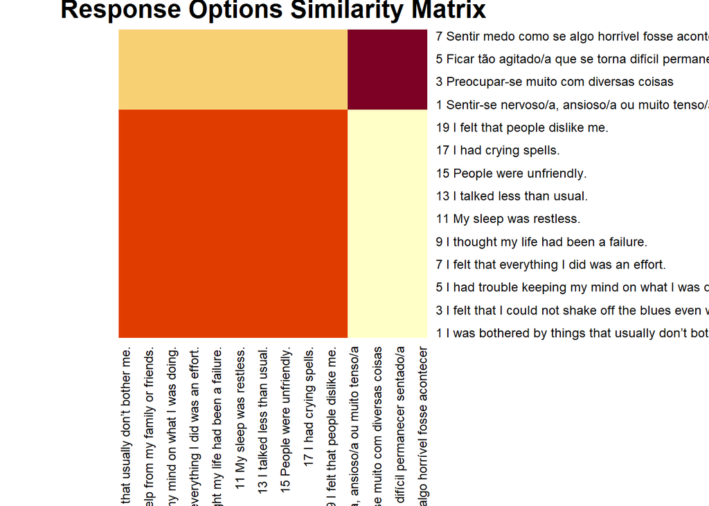

```r
heatmap(as.matrix(match$response_options_similarity),
        Rowv = NA, Colv = NA, main = "Response Options Similarity Matrix",
        margins = c(10, 10))
```

## Generate a Crosswalk table

We can generate a crosswalk table to match questions with a cosine similarity above a certain threshold.

```r
threshold <- 0.7

df_crosswalk_table <- generate_crosswalk_table(
    match$instruments,
    match$matches,
    threshold,
    is_allow_within_instrument_matches = TRUE,
    is_enforce_one_to_one = TRUE
)

df_crosswalk_table
```

[output not shown]

## Cluster the questions

Display the clusters and cluster keywords that come out of Harmony by default.

```r
for (i in seq_along(match$clusters)) {
    print(paste0("Cluster ", match$clusters[[i]]$cluster_id, ": ", match$clusters[[i]]$text_description))

    keywords <- c()
    for (j in seq_along(match$clusters[[i]]$keywords)) {
        keywords <- c(keywords, match$clusters[[i]]$keywords[[j]])
    }
    keywords_output <- paste("Keywords:", paste(keywords, collapse = ", "))
    print(keywords_output)

    for (j in seq_along(match$clusters[[i]]$item_ids)) {
        id <- match$clusters[[i]]$item_ids[[j]]
        print(paste("    ", match$questions[[id]]$question_text))
    }
}
```

```
## [1] "Cluster 1: I was happy."
## [1] "Keywords: happy, enjoyed, hopeful, future"
## [1] "     I felt I was just as good as other people."
## [1] "     I felt hopeful about the future."
## [1] "     I was happy."
## [1] "     I enjoyed life."
## [1] "Cluster 2: I talked less than usual."
## [1] "Keywords: unfriendly, talked, less"
## [1] "     I was bothered by things that usually don’t bother me."
## [1] "     I talked less than usual."
## [1] "     People were unfriendly."
## [1] "Cluster 3: I felt sad."
## [1] "Keywords: sad, fearful, lonely, depressed, felt"
## [1] "     I did not feel like eating; my appetite was poor."
## [1] "     I felt depressed."
```

[output cut: 26 more lines]

We can also choose between different clustering algorithms for the matcher to use.

```r
match <- match_instruments(instruments_list, clustering_algorithm = "kmeans")

for (i in seq_along(match$clusters)) {
    print(paste0("Cluster ", match$clusters[[i]]$cluster_id, ": ", match$clusters[[i]]$text_description))

    keywords <- c()
    for (j in seq_along(match$clusters[[i]]$keywords)) {
        keywords <- c(keywords, match$clusters[[i]]$keywords[[j]])
    }
    keywords_output <- paste("Keywords:", paste(keywords, collapse = ", "))
    print(keywords_output)

    for (j in seq_along(match$clusters[[i]]$item_ids)) {
        id <- match$clusters[[i]]$item_ids[[j]]
        print(paste("    ", match$questions[[id]]$question_text))
    }
}
```

```
## [1] "Cluster 3: I was bothered by things that usually don’t bother me."
## [1] "Keywords: unfriendly, talked"
## [1] "     I was bothered by things that usually don’t bother me."
## [1] "     I had trouble keeping my mind on what I was doing."
## [1] "     I talked less than usual."
## [1] "     People were unfriendly."
## [1] "     Não ser capaz de impedir ou de controlar as preocupações"
## [1] "     Preocupar-se muito com diversas coisas"
## [1] "     Ikke klart å slutte å bekymre deg eller kontrolleren bekymringene dine"
## [1] "Cluster 2: I did not feel like eating; my appetite was poor."
## [1] "Keywords: ficar, dificuldade, relaxar, facilmente"
## [1] "     I did not feel like eating; my appetite was poor."
## [1] "     Sentir-se nervoso/a, ansioso/a ou muito tenso/a"
## [1] "     Dificuldade para relaxar"
## [1] "     Ficar tão agitado/a que se torna difícil permanecer sentado/a"
```

[output cut: 24 more lines]

## Display the similarities between instruments

Let’s display the similarities between the instruments.

```r
for (i in seq_along(match$instrument_to_instrument_similarities)) {
    obj <- match$instrument_to_instrument_similarities[[i]]
    print(paste("F1 similarity of", obj$instrument_1_name, "to", obj$instrument_2_name, "is", obj$f1))
}
```

```
## [1] "F1 similarity of CES_D English to GAD-7 Portuguese is 0.675"
## [1] "F1 similarity of CES_D English to GAD-7 Norwegian is 0.55"
## [1] "F1 similarity of GAD-7 Portuguese to GAD-7 Norwegian is 0.642857142857143"
```

## Saving to CSV/Excel

We can simply export the `match$matches` data frame to a CSV file.

```r
write.csv(match$matches, "matches.csv")
```

Similarly we can export `df_crosswalk_table`.

```r
write.csv(df_crosswalk_table, "crosswalk_table.csv")
```

If you open the CSV generated, you can see the complete matrix. You can also open in Excel.

You can also see the file in Google Colab online by going into the file system on the left panel (see below screenshot).

[figure not shown]

Screenshot

```r
#system("head matches.csv", intern = TRUE)
```